# Exploring Movie Industry Trends: An In-Depth Data Analysis

Author

Vinayak Sikka

Published

December 15, 2024

## Introduction

In this project, we delve into the diverse world of cinema, exploring a rich dataset of movies to uncover patterns and trends that shape the film industry. Our analysis aims to reveal insights into genre popularity, financial aspects such as budgets and revenues, and the critical reception of films over time. By examining these elements, we seek to understand the dynamics that contribute to a movie’s success and the evolving preferences of audiences worldwide. This exploration not only provides a snapshot of the current cinematic landscape but also offers a lens through which we can predict future trends.

## Description of the problem

My investigation centers on unraveling key questions within the movie industry, guided by the comprehensive movies dataset at our disposal. Specifically, we aim to address the following problems:

Genre Trends: What genres are currently dominating the film industry in terms of quantity and audience preference? By identifying the most popular genres, we can gauge shifts in audience tastes over time and predict future trends.

Box Office Success: What factors contribute to a movie’s financial success? We seek to explore the relationship between a film’s budget, its genre, and its revenue to understand what drives box office success.

Critical Reception vs. Financial Performance: How does a movie’s critical reception relate to its financial performance? This analysis will help us determine if critically acclaimed movies tend to perform better financially or if there’s a disconnect between critics’ ratings and box office revenue.

Temporal Dynamics: How have the trends in movie genres, budgets, and revenues evolved over the years? By examining these elements over time, we aim to uncover the evolution of the film industry and predict where it might be headed.

Through addressing these questions, we not only aim to provide a thorough analysis of the current state of the movie industry but also offer insights that could inform producers, directors, and marketers in their future projects. This project seeks to bridge the gap between cinematic art and its commercial success, offering a data-driven perspective on what makes a movie resonate with audiences and thrive financially.

## Exploratory Data Analysis

| name | rating | genre | year | released | score | votes | director | writer | star | country | budget | gross | company | runtime |
| --- | --- | --- | --- | --- | --- | --- | --- | --- | --- | --- | --- | --- | --- | --- |
| The Shawshank Redemption | R | Drama | 1994 | October 14, 1994 (United States) | 9.3 | 2400000 | Frank Darabont | Stephen King | Tim Robbins | United States | 2.50e+07 | 28817291 | Castle Rock Entertainment | 142 |
| The Dark Knight | PG-13 | Action | 2008 | July 18, 2008 (United States) | 9.0 | 2400000 | Christopher Nolan | Jonathan Nolan | Christian Bale | United States | 1.85e+08 | 1005973645 | Warner Bros. | 152 |
| Schindler’s List | R | Biography | 1993 | February 4, 1994 (United States) | 8.9 | 1200000 | Steven Spielberg | Thomas Keneally | Liam Neeson | United States | 2.20e+07 | 322161245 | Universal Pictures | 195 |
| Pulp Fiction | R | Crime | 1994 | October 14, 1994 (United States) | 8.9 | 1900000 | Quentin Tarantino | Quentin Tarantino | John Travolta | United States | 8.00e+06 | 213928762 | Miramax | 154 |
| The Lord of the Rings: The Return of the King | PG-13 | Action | 2003 | December 17, 2003 (United States) | 8.9 | 1700000 | Peter Jackson | J.R.R. Tolkien | Elijah Wood | New Zealand | 9.40e+07 | 1146030912 | New Line Cinema | 201 |
| Forrest Gump | PG-13 | Drama | 1994 | July 6, 1994 (United States) | 8.8 | 1900000 | Robert Zemeckis | Winston Groom | Tom Hanks | United States | 5.50e+07 | 678226133 | Paramount Pictures | 142 |
| Fight Club | R | Drama | 1999 | October 15, 1999 (United States) | 8.8 | 1900000 | David Fincher | Chuck Palahniuk | Brad Pitt | Germany | 6.30e+07 | 101209702 | Fox 2000 Pictures | 139 |
| The Lord of the Rings: The Fellowship of the Ring | PG-13 | Action | 2001 | December 19, 2001 (United States) | 8.8 | 1700000 | Peter Jackson | J.R.R. Tolkien | Elijah Wood | New Zealand | 9.30e+07 | 897690072 | New Line Cinema | 178 |
| Inception | PG-13 | Action | 2010 | July 16, 2010 (United States) | 8.8 | 2100000 | Christopher Nolan | Christopher Nolan | Leonardo DiCaprio | United States | 1.60e+08 | 836836967 | Warner Bros. | 148 |
| Star Wars: Episode V - The Empire Strikes Back | PG | Action | 1980 | June 20, 1980 (United States) | 8.7 | 1200000 | Irvin Kershner | Leigh Brackett | Mark Hamill | United States | 1.80e+07 | 538375067 | Lucasfilm | 124 |

```
[1] 2473
```

| YEAR_mean | YEAR_sd | IMDB_RATING_mean | IMDB_RATING_sd | VOTES_mean | VOTES_sd | BUDGET_mean | BUDGET_sd | GROSS_mean | GROSS_sd | RUNTIME_mean | RUNTIME_sd |
| --- | --- | --- | --- | --- | --- | --- | --- | --- | --- | --- | --- |
| 2000.405 | 11.15351 | 6.390411 | 0.9688416 | 88108.5 | 163323.8 | 35589876 | 41457297 | 78500541 | 165725124 | 107.2616 | 18.58125 |

| NAME | RATING | GENRE | YEAR | RELEASED | IMDB_RATING | VOTES | DIRECTOR | WRITER | STAR | COUNTRY | BUDGET | GROSS | COMPANY | RUNTIME |
| --- | --- | --- | --- | --- | --- | --- | --- | --- | --- | --- | --- | --- | --- | --- |
| The Shawshank Redemption | R | Drama | 1994 | October 14, 1994 (United States) | 9.3 | 2400000 | Frank Darabont | Stephen King | Tim Robbins | United States | 2.50e+07 | 28817291 | Castle Rock Entertainment | 142 |
| The Dark Knight | PG-13 | Action | 2008 | July 18, 2008 (United States) | 9.0 | 2400000 | Christopher Nolan | Jonathan Nolan | Christian Bale | United States | 1.85e+08 | 1005973645 | Warner Bros. | 152 |
| Schindler's List | R | Biography | 1993 | February 4, 1994 (United States) | 8.9 | 1200000 | Steven Spielberg | Thomas Keneally | Liam Neeson | United States | 2.20e+07 | 322161245 | Universal Pictures | 195 |
| Pulp Fiction | R | Crime | 1994 | October 14, 1994 (United States) | 8.9 | 1900000 | Quentin Tarantino | Quentin Tarantino | John Travolta | United States | 8.00e+06 | 213928762 | Miramax | 154 |
| The Lord of the Rings: The Return of the King | PG-13 | Action | 2003 | December 17, 2003 (United States) | 8.9 | 1700000 | Peter Jackson | J.R.R. Tolkien | Elijah Wood | New Zealand | 9.40e+07 | 1146030912 | New Line Cinema | 201 |
| Forrest Gump | PG-13 | Drama | 1994 | July 6, 1994 (United States) | 8.8 | 1900000 | Robert Zemeckis | Winston Groom | Tom Hanks | United States | 5.50e+07 | 678226133 | Paramount Pictures | 142 |
| Fight Club | R | Drama | 1999 | October 15, 1999 (United States) | 8.8 | 1900000 | David Fincher | Chuck Palahniuk | Brad Pitt | Germany | 6.30e+07 | 101209702 | Fox 2000 Pictures | 139 |
| The Lord of the Rings: The Fellowship of the Ring | PG-13 | Action | 2001 | December 19, 2001 (United States) | 8.8 | 1700000 | Peter Jackson | J.R.R. Tolkien | Elijah Wood | New Zealand | 9.30e+07 | 897690072 | New Line Cinema | 178 |
| Inception | PG-13 | Action | 2010 | July 16, 2010 (United States) | 8.8 | 2100000 | Christopher Nolan | Christopher Nolan | Leonardo DiCaprio | United States | 1.60e+08 | 836836967 | Warner Bros. | 148 |
| Star Wars: Episode V - The Empire Strikes Back | PG | Action | 1980 | June 20, 1980 (United States) | 8.7 | 1200000 | Irvin Kershner | Leigh Brackett | Mark Hamill | United States | 1.80e+07 | 538375067 | Lucasfilm | 124 |

Top Director by Movies with High Scores

Directors with the most movies scoring 7 or more

| DIRECTOR | Count |
| --- | --- |
| Steven Spielberg | 21 |

## Data Visualization

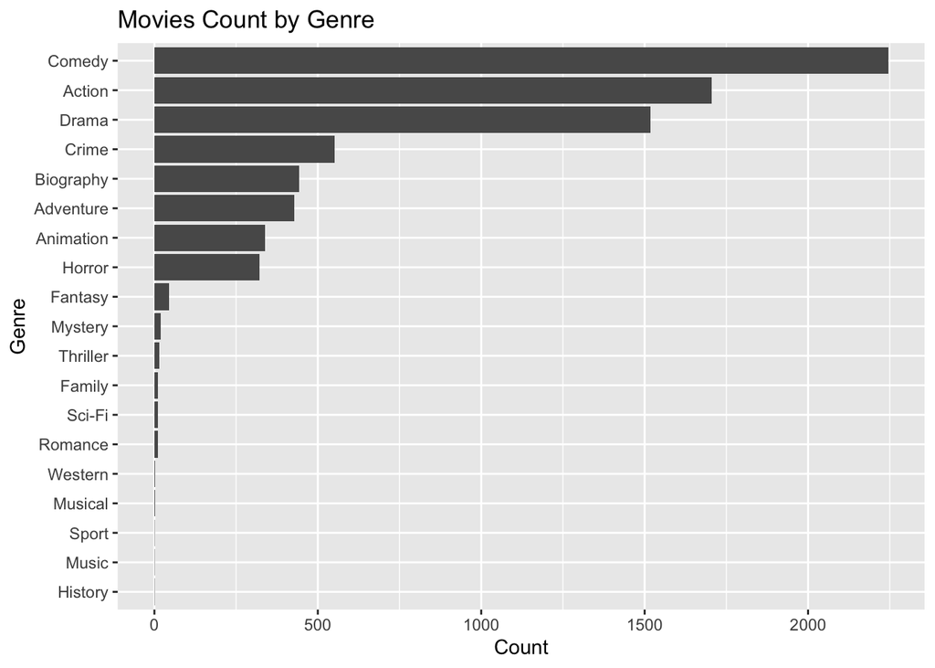

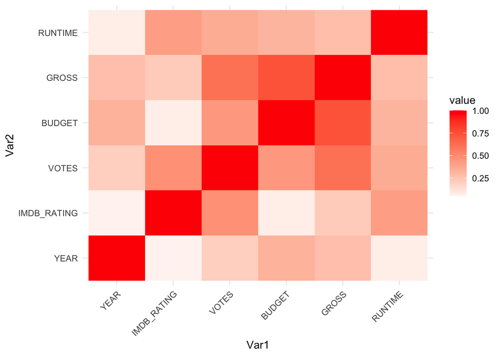

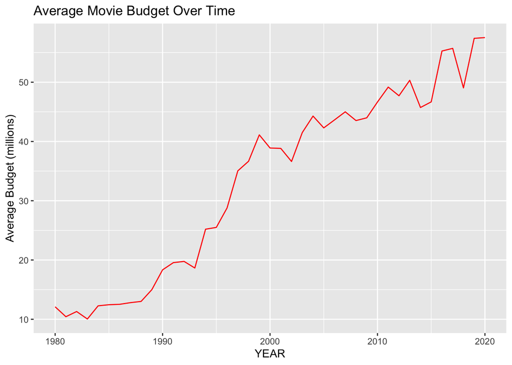

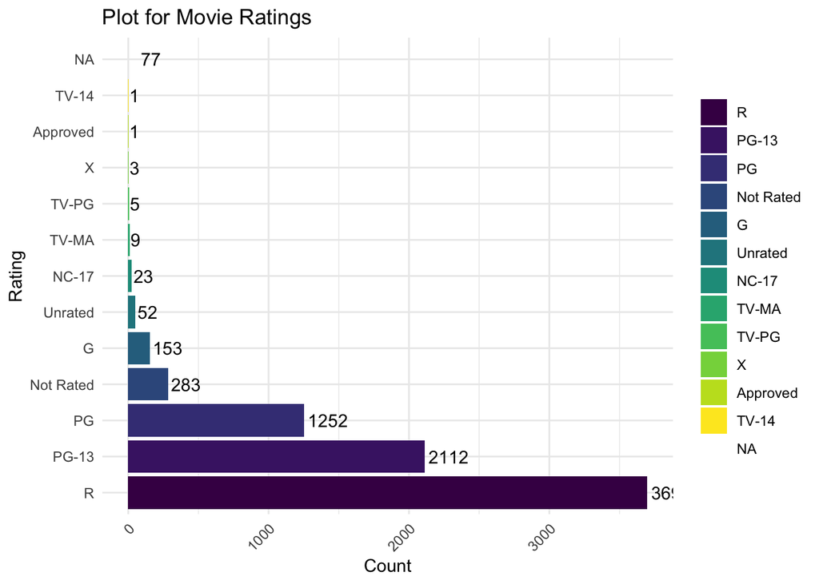

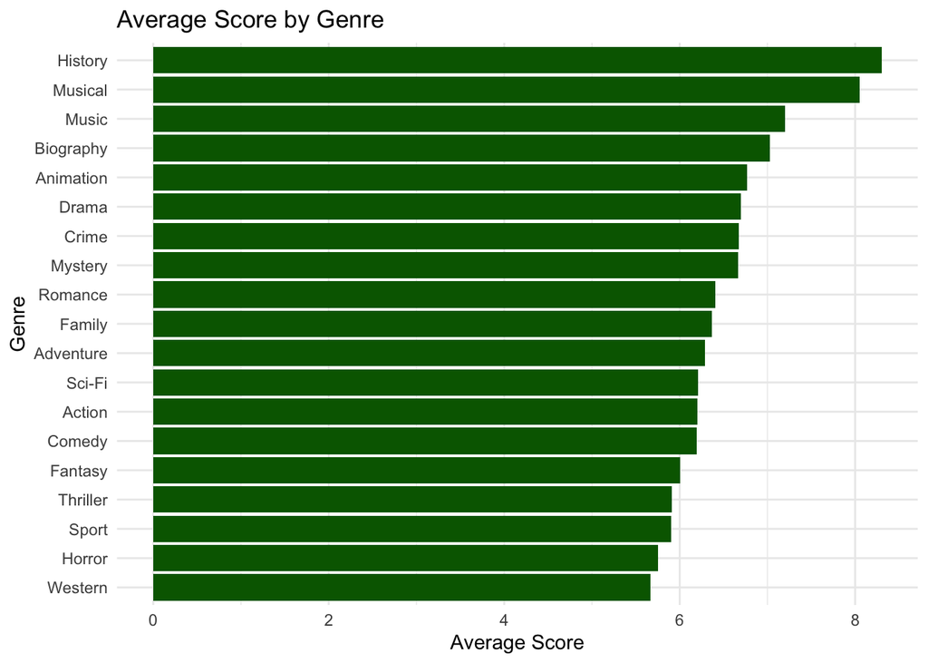